# Desafio

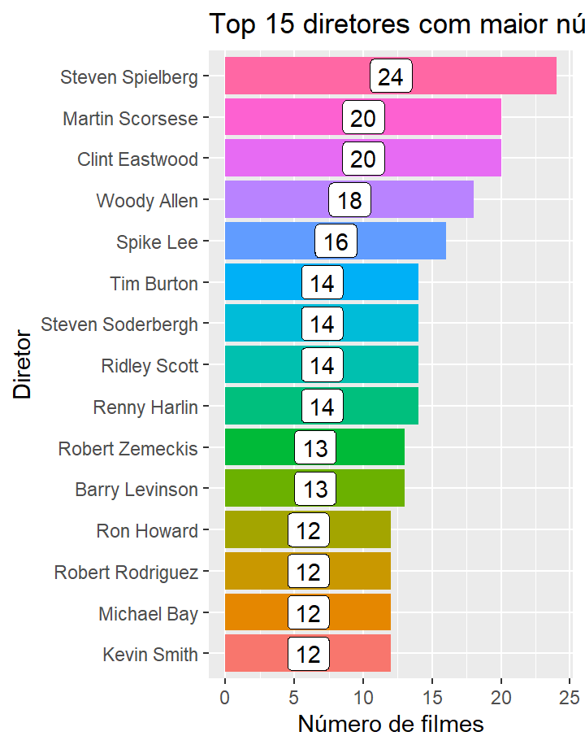

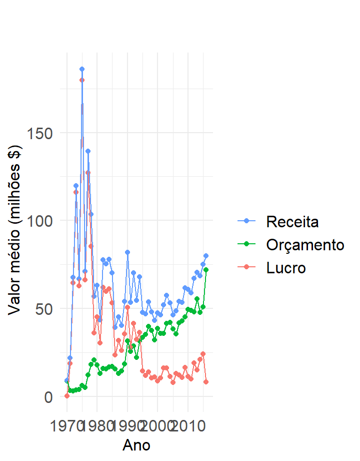

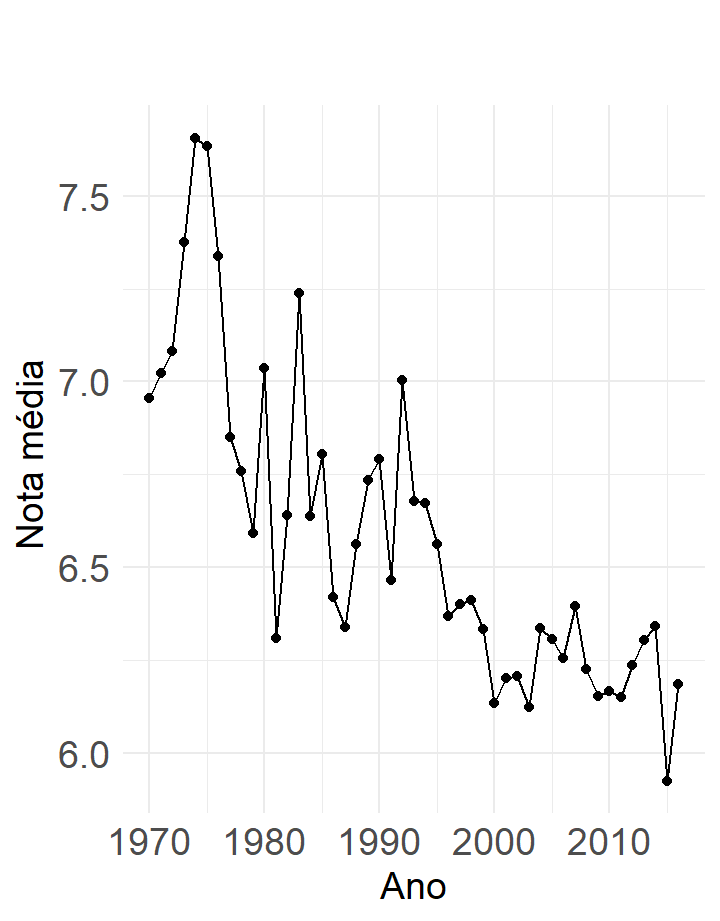

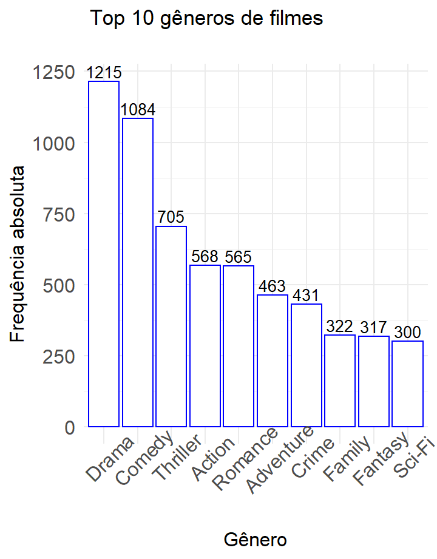

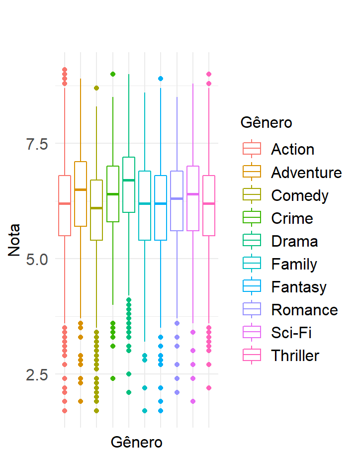

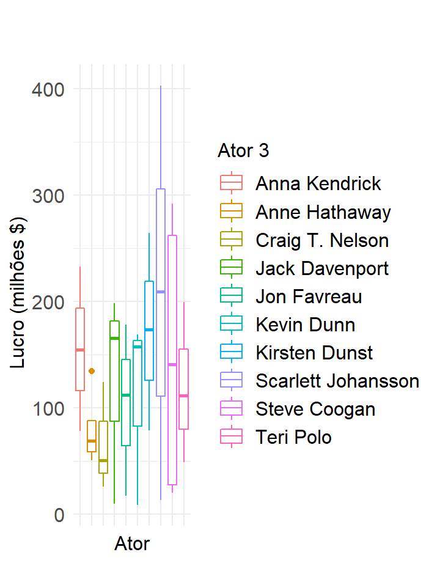

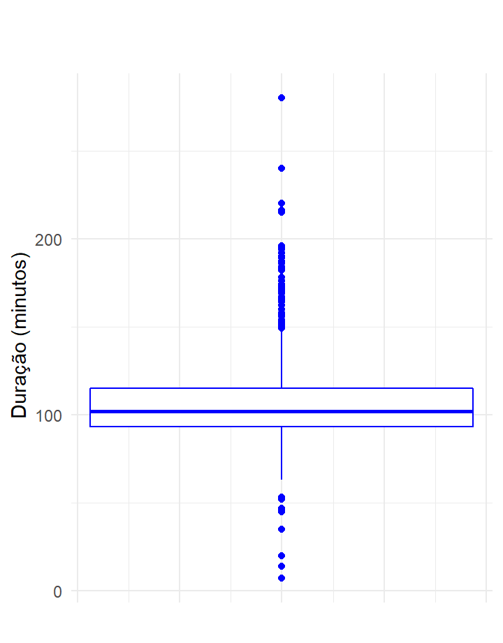

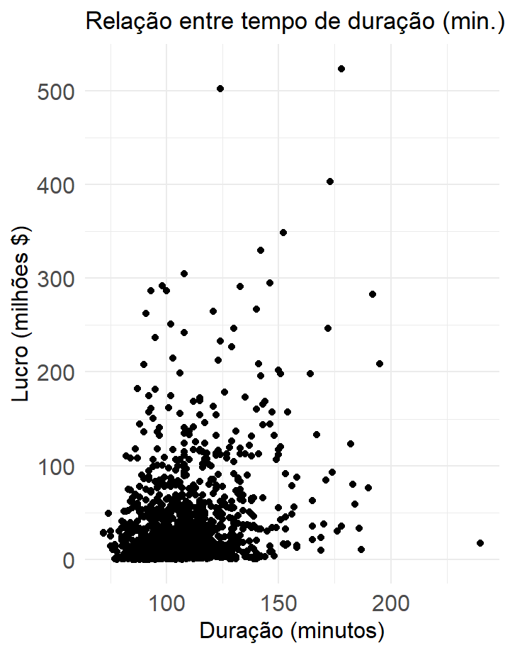

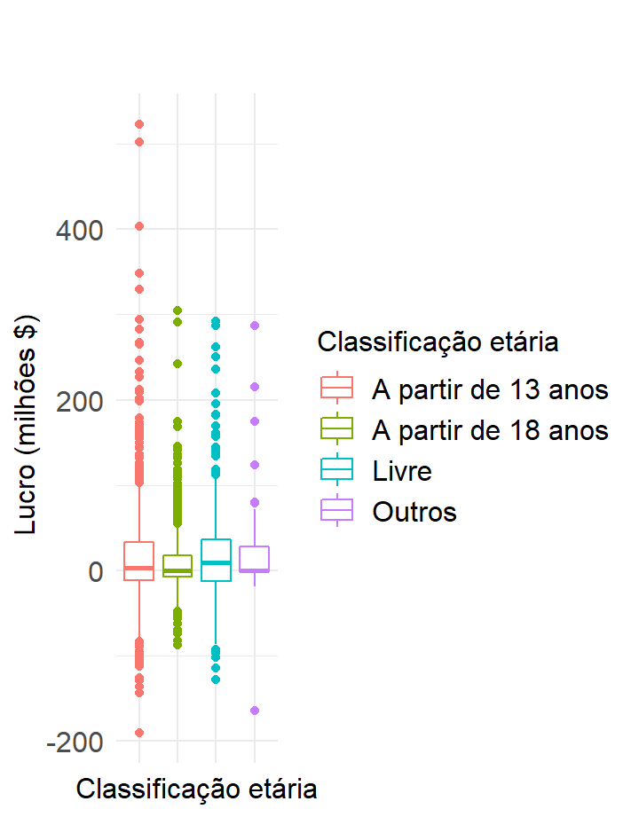

# Problema

**Análise da base IMDB**

**Desafio proposto aos alunos do curso de R para Ciência de Dados I**

**Aluna:** Camila Bertini Martins

**Objetivo:** fazer uma análise exploratória dos dados do IMDB.

**Contexto:** imaginem que o Athos e o William queiram investir na produção de um filme, mas eles não sabem nada de cinema. Eles tem interesse em produzir um filme que seja tanto um sucesso financeiro, quanto um sucesso de crítica, mas poderiam abandonar um dos critérios caso o outro seja muito atraente. Para isso, eles precisam saber quais os melhores diretores, atores e qual gênero de filme é mais propenso a uma produção de sucesso. Informações sobre duração e classificação etária também seriam interessantes para eles, assim como uma ideia do quanto eles precisariam desembolsar.

# Diretor

### **Diretores que fizeram mais de 3 filmes, a partir do ano de 2000, com lucro positivo**

| Diretor | Número de filmes | Nota Média | Lucro Médio (milhões $) | Duração média (min.) |
| --- | --- | --- | --- | --- |
| Adam McKay | 5 | 7.04 | $46,054,876 | 114.4 |
| Adam Shankman | 5 | 6.22 | $45,230,955 | 103.2 |
| Alexander Payne | 4 | 7.45 | $40,687,708 | 120.25 |
| Andy Fickman | 6 | 5.77 | $30,572,289 | 102.83 |
| Andy Tennant | 4 | 5.95 | $56,018,660 | 112 |
| Antoine Fuqua | 5 | 7.12 | $27,852,104 | 125.8 |
| Bobby Farrelly | 4 | 5.93 | $25,790,103 | 109.5 |
| Carlos Saldanha | 4 | 6.83 | $76,014,468 | 101.5 |
| Christopher Nolan | 7 | 8.41 | $113,099,527 | 144.14 |
| Clint Eastwood | 6 | 7.52 | $91,884,418 | 131.67 |

[output cut: 34 more lines]

### **Top 15 diretores com maior número de filmes produzidos a partir de 1970**

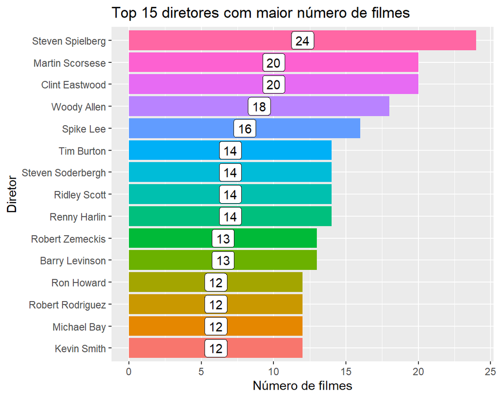

# Bilheteria

### **50 filmes com maior lucro produzidos a partir de 2000**

| Título | Lucro ($) |
| --- | --- |
| Avatar | $523,505,847 |
| Jurassic World | $502,177,271 |
| The Avengers | $403,279,547 |
| The Dark Knight | $348,316,061 |
| The Hunger Games | $329,999,255 |
| Deadpool | $305,024,263 |
| The Hunger Games: Catching Fire | $294,645,577 |
| Despicable Me 2 | $292,049,635 |
| American Sniper | $291,323,553 |
| Finding Nemo | $286,838,870 |

[output cut: 40 more lines]

### **Séries do orçamento médio, receita média e lucro médio dos filmes produzidos a partir de 1970**

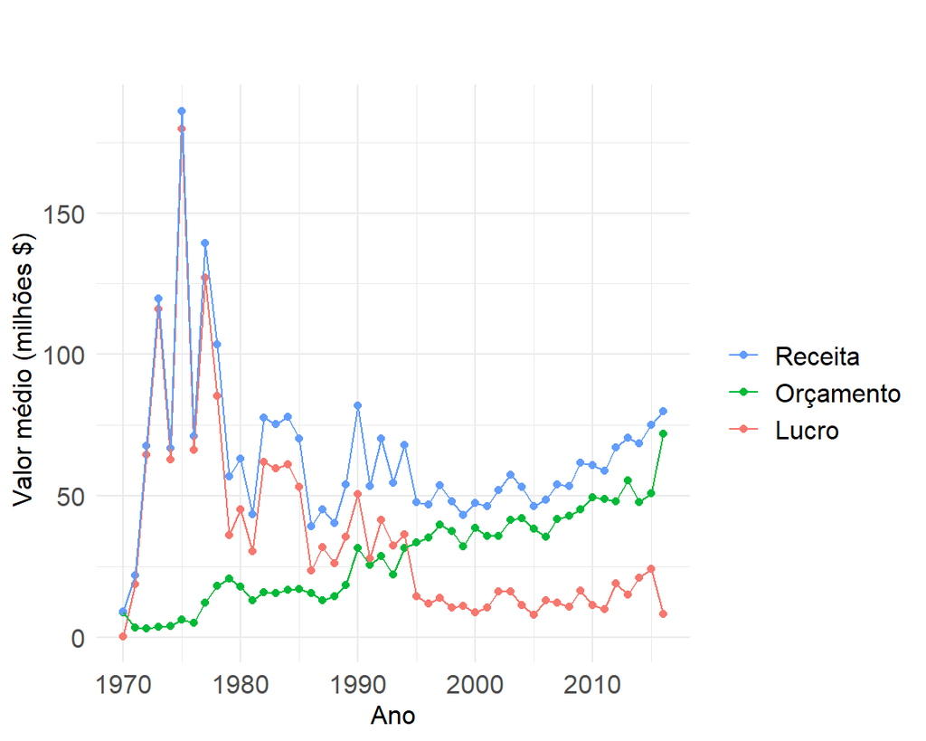

# Notas

### **Filmes com maiores notas produzidos a partir de 2000**

| Título | Diretor | Nota |
| --- | --- | --- |
| Kickboxer: Vengeance | John Stockwell | 9.1 |
| The Dark Knight | Christopher Nolan | 9 |
| The Lord of the Rings: The Return of the King | Peter Jackson | 8.9 |
| Inception | Christopher Nolan | 8.8 |
| The Lord of the Rings: The Two Towers | Peter Jackson | 8.7 |
| A Beginner's Guide to Snuff | Mitchell Altieri | 8.7 |
| Butterfly Girl | Cary Bell | 8.7 |
| Interstellar | Christopher Nolan | 8.6 |
| Running Forever | Mike Mayhall | 8.6 |
| The Dark Knight Rises | Christopher Nolan | 8.5 |

[output cut: 58 more lines]

### **Série nota média anual a partir de 1970**

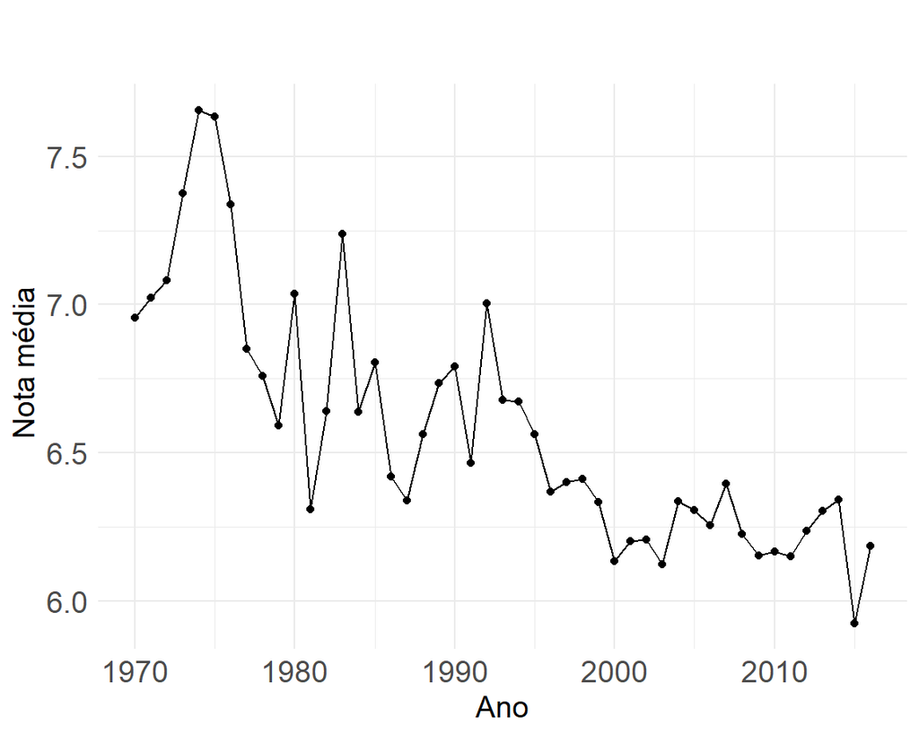

# Gênero

### **TOP 10: Distribuição do gênero dos filmes produzidos a partir de 2000**

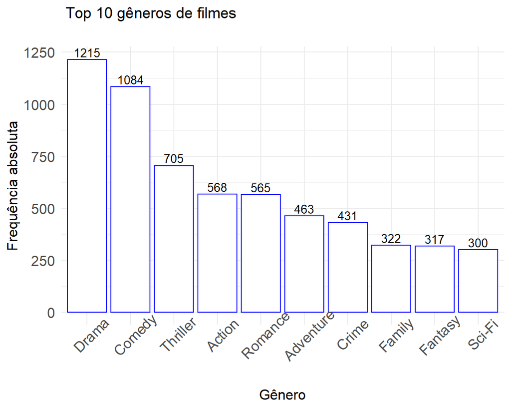

### **TOP 10: Distribuição do lucro (milhões $) e da nota por gênero, filmes produzidos a partir de 2000**

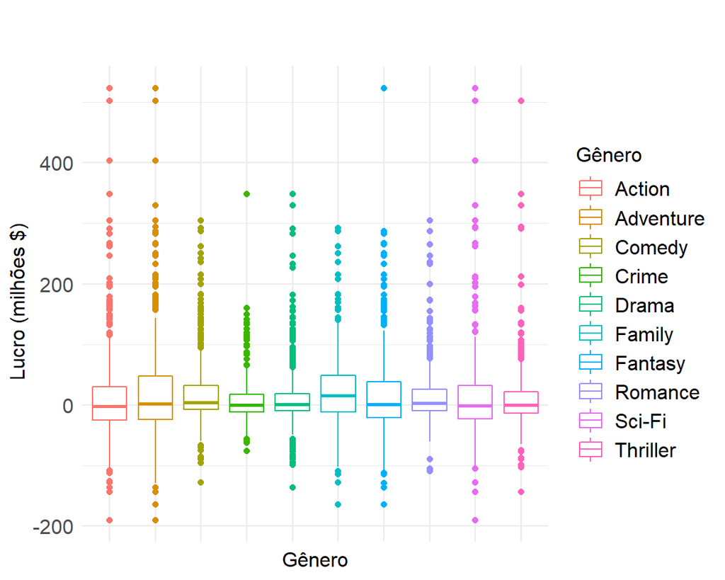

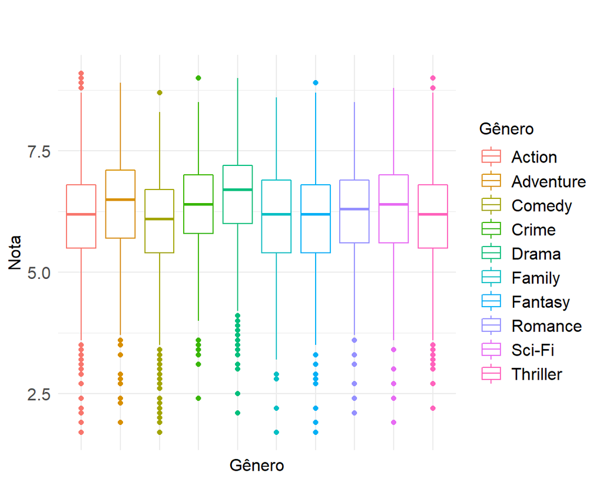

# Ator

### **Nota média e lucro médio (milhões $) por ator principal que teve lucro positivo (apartir de 2000)**

| Ator 1 | Lucro médio (milhões $) | Nota média | Número de filmes |
| --- | --- | --- | --- |
| Adam Garcia | 15.79 | 5.6 | 1 |
| Adam Goldberg | 63.39 | 6.6 | 2 |
| Adam LeFevre | 0.44 | 7.2 | 1 |
| Adam Sandler | 42.05 | 6.3 | 6 |
| Adam Scott | 10.39 | 6.2 | 3 |
| Ahna O'Reilly | 15.2 | 7.5 | 1 |
| Aidan Quinn | 1.25 | 7.3 | 1 |
| Aidan Turner | 78.18 | 7.9 | 2 |
| Al Pacino | 26.7 | 7.1 | 2 |
| Albert Brooks | 108.13 | 7.4 | 1 |

[output cut: 582 more lines]

### **TOP 10: Distribuição do lucro ($) por ator que teve lucro positivo, fez 3 filmes ou mais a partir de 2000**

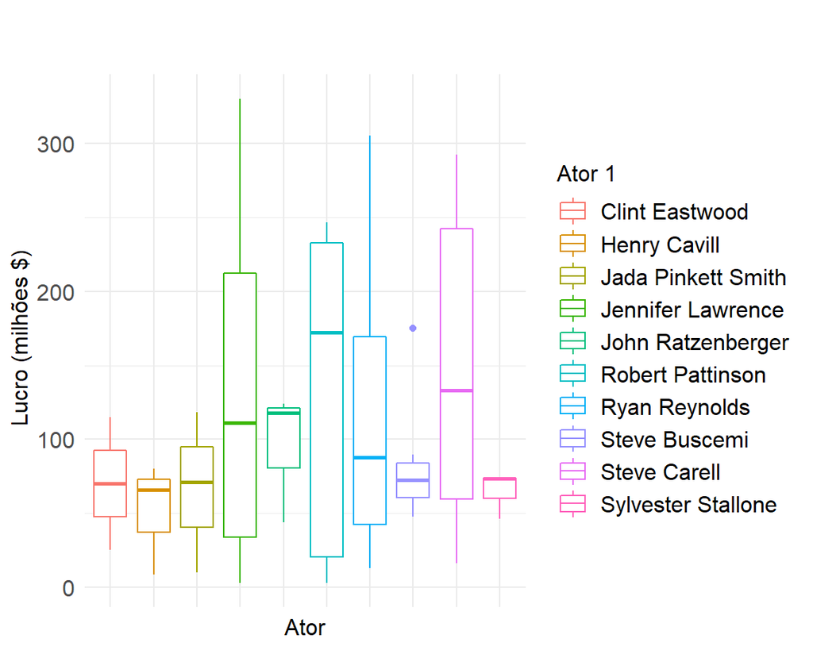

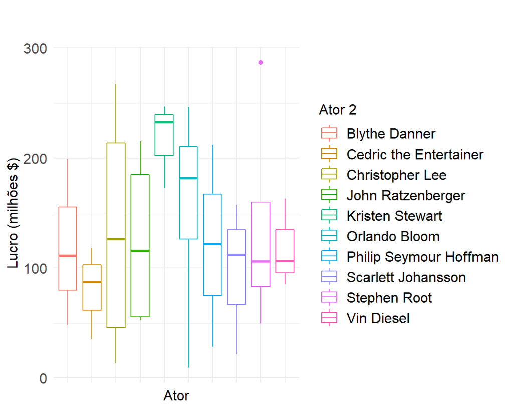

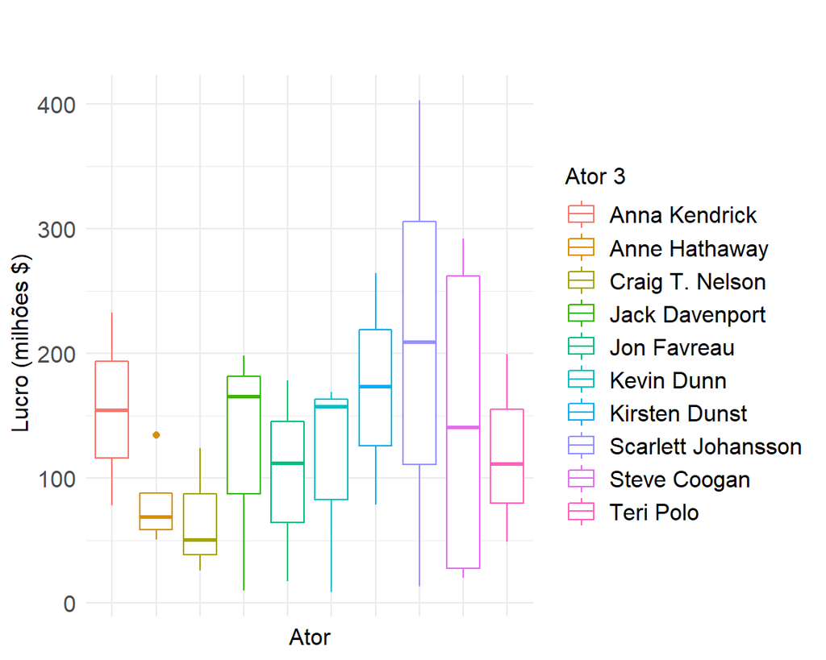

# Duração

### **Distribuição do tempo de duração dos filmes produzidos a partir de 2000**

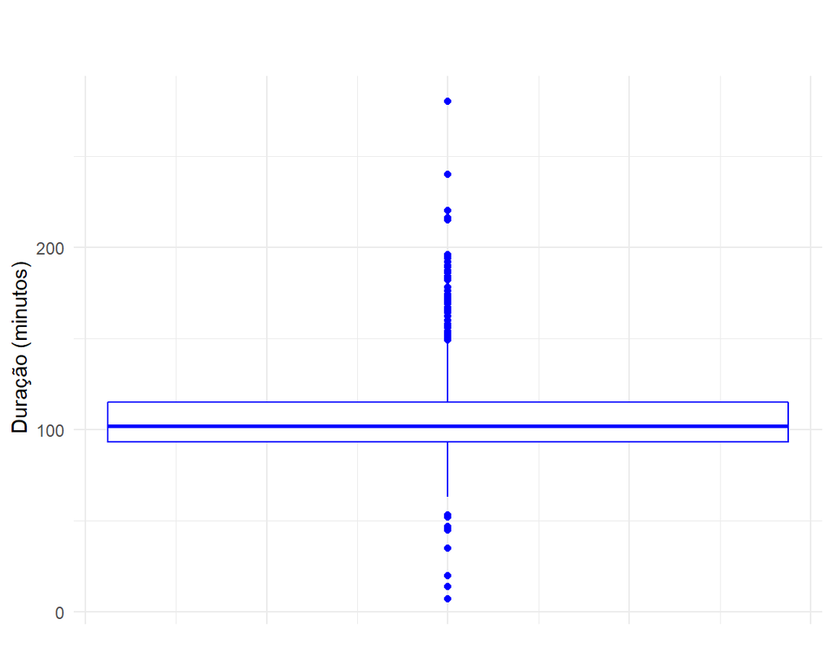

### **Filmes produzidos a partir de 2000 e com lucro positivo**

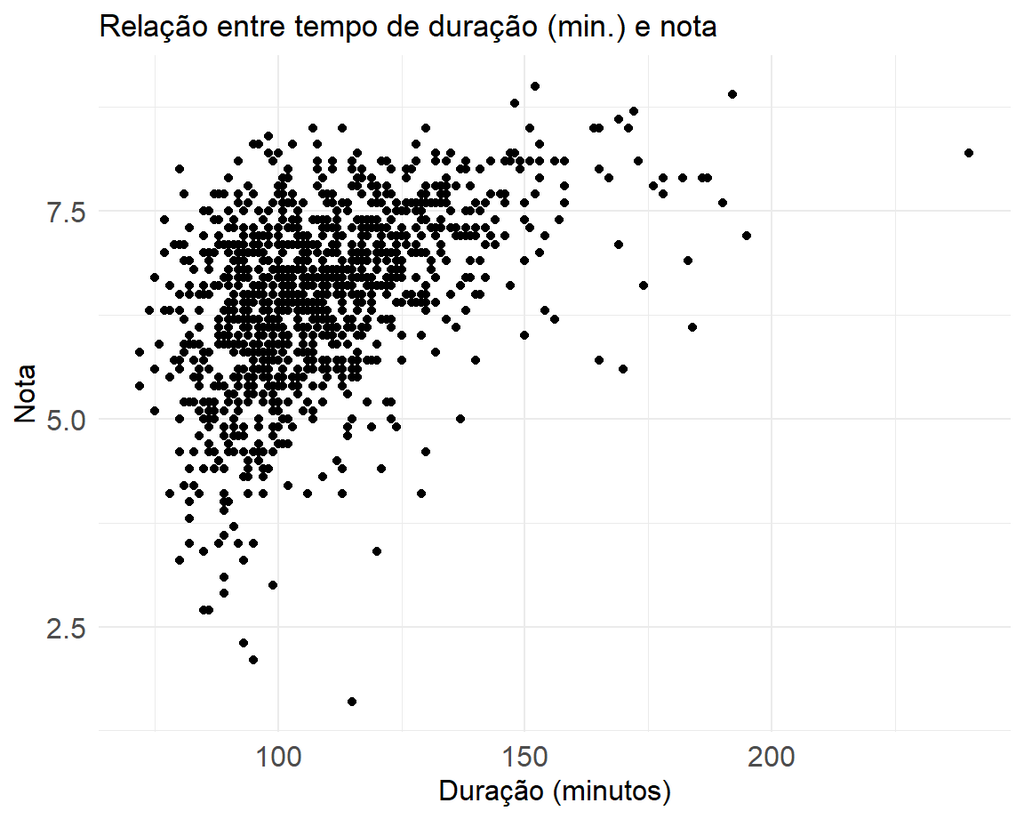

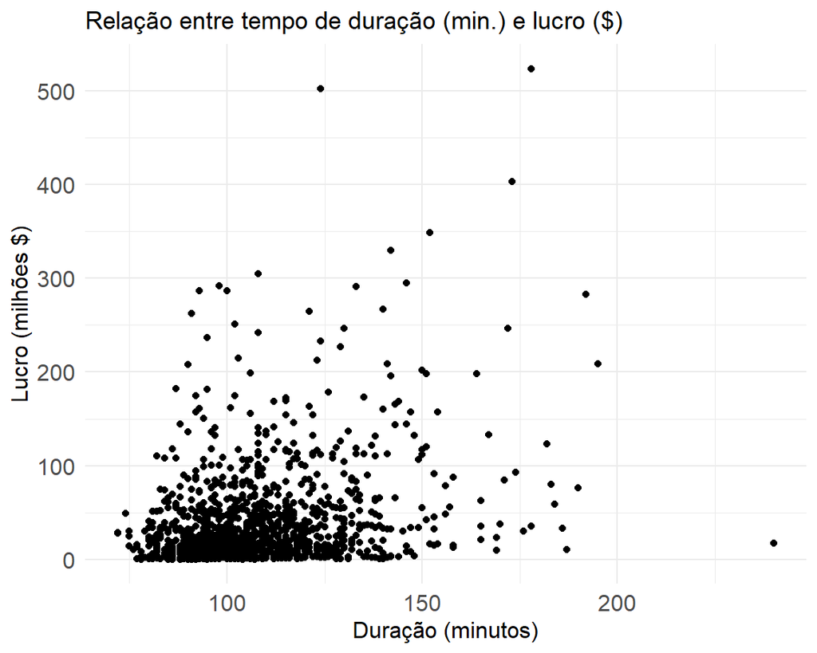

# Classificação etária

### **Filmes produzidos a partir de 2000 e com lucro positivo**

| Classificação etária | Número de filmes | Nota Média | Lucro Médio (milhões $) | Duração média (min) |
| --- | --- | --- | --- | --- |
| A partir de 13 anos | 457 | 6.41 | $50,222,459 | 112.18 |
| A partir de 18 anos | 403 | 6.68 | $30,114,303 | 108.45 |
| Livre | 191 | 6.27 | $47,114,607 | 99.74 |
| Outros | 33 | 6.38 | $53,611,002 | 97.15 |

### **Distribuição do lucro (milhões $) por classificação etária de filmes produzidos a partir de 2000**

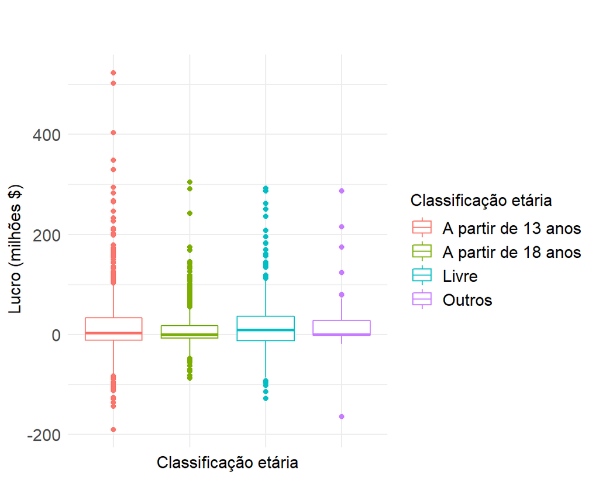